# Correlations between EWS and effective reproduction number

To complement the fixed window analysis focused on emergence and elimination events, we also want to show that the dynamics of EWS reflect those of $R_E$. I estimated $R_E$ over the observations via particle filtering and state estimation. Here, I read in those values for each city and correlate them with top-performing EWS. Top-performing EWS are those with high AUC in the emergence and elimination scenarios. Note that $R_E$ was calculated as:

$$R_E = \frac{\beta_t}{(\gamma + \eta)} \frac{S_t}{N_t}.$$

```r
library(tidyverse)
cities <- c("Agadez", "Maradi", "Niamey", "Zinder")  # the four city names
reffs <- tibble()  # empty tibble for storage
for(do_city in cities){
  fname <- paste0("../../results/filtered-states-", do_city, ".RDS")
  raw_filter <- readRDS(fname)
  reff_id <- which(raw_filter$state == "effective_r_seasonal")
  tmp_reff <- raw_filter$data[[reff_id]] %>%
    dplyr::select(time, med, week, date) %>%
    dplyr::mutate(city = do_city)

  reffs <- bind_rows(reffs, tmp_reff)
}
ggplot(reffs, aes(x = date, y = med, color = city)) +
  geom_hline(aes(yintercept = 1), linetype = 2, color = "grey35") +
  geom_line() +
  labs(x = "date", y = expression(italic(R)[E]),
       title = "Effective reproduction number over time") +
  ggthemes::scale_color_colorblind()
```

[output not shown]

Now I calculate the EWS at each observation time using the `spaero::get_stats()` function. I use a bandwidth of 35 weeks and set `backward_only = TRUE` so that only past data are used when calculating EWS.

```r
library(spaero)
fname <- "../../data/clean-data/weekly-measles-incidence-niger-cities-clean.RDS"
measles_data <- readRDS(fname) %>%
  filter(year > 1994)  # drop first NA year, only used for modeling
all_stats <- tibble()  # empty tibble for storage
for(do_region in unique(measles_data$region)){

  cases <- measles_data %>%
    filter(region == do_region) %>%
    pull(cases)

  city_stats <- spaero::get_stats(
    x = cases,
    center_trend = "local_constant",
    center_kernel = "uniform",
    center_bandwidth = 35,
    stat_trend = "local_constant",
    stat_kernel = "uniform",
    stat_bandwidth = 35,
    lag = 1,
    backward_only = TRUE
  )$stats

  city_stats_tb <- as_tibble(city_stats) %>%
    mutate(
      time_iter = 1:n(),
      date = unique(measles_data$date)
    ) %>%
    gather(key = ews, value = value, -time_iter, -date) %>%
    mutate(region = do_region)

  all_stats <- bind_rows(all_stats, city_stats_tb)
}
best_ews <- c("autocorrelation", "autocovariance", "mean", "variance")
all_stats <- all_stats %>%
  dplyr::filter(ews %in% best_ews)
```

Now I look at scatterplots of $R_E$ versus EWS.

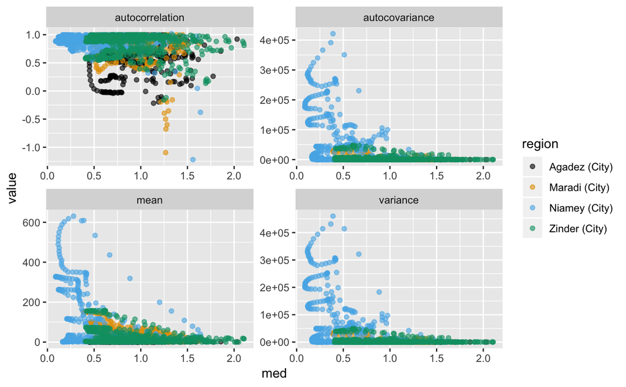

```r
reffs <- reffs %>%
  dplyr::mutate(region = paste0(city, " (City)")) %>%
  dplyr::select(-city)
ews_reffs <- left_join(all_stats, reffs)
ggplot(ews_reffs, aes(x = med, y = value, color = region)) +
  geom_point(alpha = 0.6) +
  facet_wrap(~ews, scales = "free") +
  ggthemes::scale_color_colorblind()
```

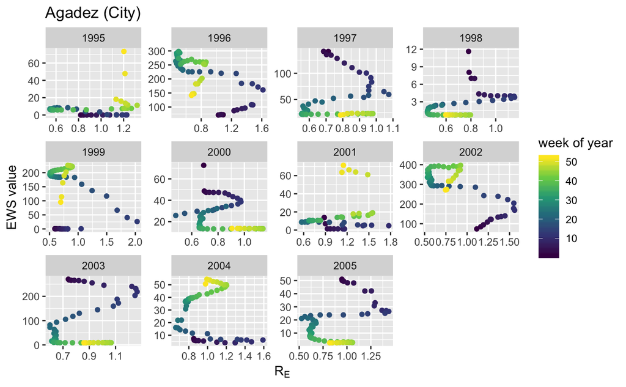

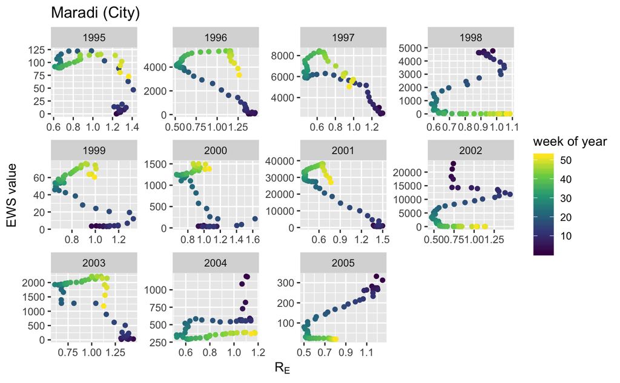

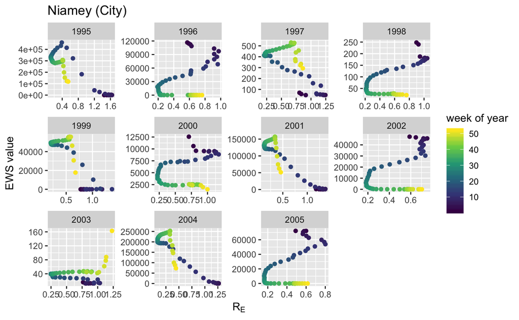

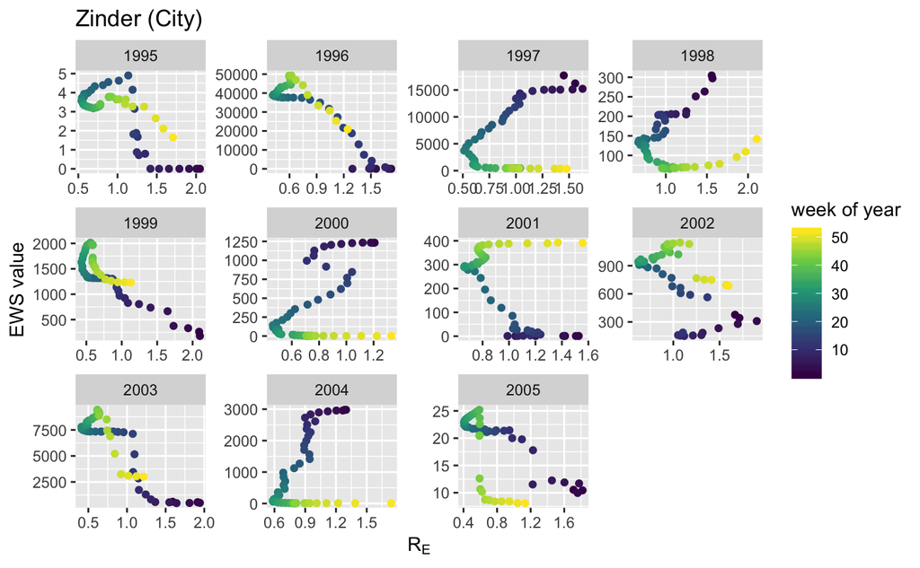

```r
for(do_region in unique(ews_reffs$region)){
  print(ggplot(filter(ews_reffs, region == do_region & ews == "variance"),
       aes(x = med, y = value, color = lubridate::week(date))) +
    geom_point() +
    facet_wrap(~lubridate::year(date), scales = "free") +
    labs(x = expression(R[E]), y = "EWS value", title = do_region) +
    scale_color_viridis_c(name = "week of year", direction = 1))
}
```

So those plots are pretty weird because of the temporal cycling. What if I remove the seasonal component via differencing?

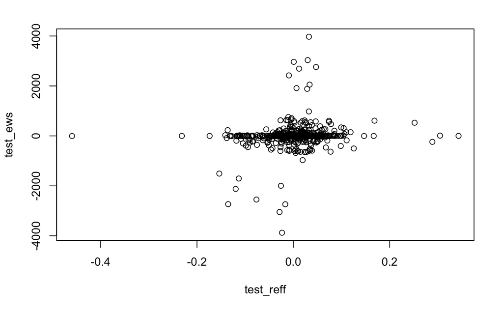

```r
test <- filter(ews_reffs, region == "Maradi (City)" & ews == "variance") %>%
  dplyr::mutate(value = dplyr::lag(value, n = 20))
test_reff <- diff(test$med)
test_ews <- diff(test$value)
plot(test_reff, test_ews)
```

```r
cor(test_reff, test_ews, method = "spearman", use = "pairwise.complete.obs")
```

```
[1] 0.1505346
```

# Rolling correlation?

The region-specific plots of $R_E$ and variance over time make it look like they are correlated at some points and not correlated at others. Wonder if a rolling correlation can do the trick?

```r
do_region <- "Maradi (City)"
variances <- ews_reffs %>%
  filter(ews == "variance" & region == do_region) %>%
  pull(value)
reffs <- ews_reffs %>%
  filter(ews == "variance" & region == do_region) %>%
  pull(med)
cases <- measles_data %>%
    filter(region == do_region) %>%
    pull(cases)
par(mfrow = c(2, 1))
plot(reffs, type = "l")
plot(variances, type = "l")
```

[output not shown]

```r
test <- zoo::rollapply(data.frame(variances,reffs), 10, function(x) cor(x[,1],x[,2]), by.column=FALSE)
df <- tibble(x = test, y = reffs[10:length(reffs)])
ggplot(df, aes(x = seq_along(x), y = y, color = x)) +
  geom_line(color = "grey35", size = 0.3) +
  geom_point() +
  geom_hline(aes(yintercept = 1), linetype = 2, color = "grey45") +
  scale_color_viridis_c(limits = c(-1,1), name = expression(paste("cor(", R[E], ", var)"))) +
  labs(x = "time", y = expression(R[E]))
# df <- tibble(x = variances[10:length(reffs)], y = reffs[10:length(reffs)])
# ggplot(df, aes(x = seq_along(x), y = y, color = sqrt(x))) +
#   geom_line(color = "grey35", size = 0.3) +
#   geom_point() +
#   geom_hline(aes(yintercept = 1), linetype = 2, color = "grey45") +
#   scale_color_viridis_c(name = "variance") +
#   labs(x = "time", y = expression(R[E]))
#
df <- tibble(x = reffs, y = cases)
ggplot(df, aes(x = seq_along(x), y = y, color = sqrt(x))) +
  geom_line(color = "grey35", size = 0.3) +
  geom_point() +
  geom_hline(aes(yintercept = 1), linetype = 2, color = "grey45") +
  scale_color_viridis_c(name = expression(R[E]), limits = c(1,1.5)) +
  labs(x = "time", y = "cases")
```

[output not shown]

# Differencing before correlating

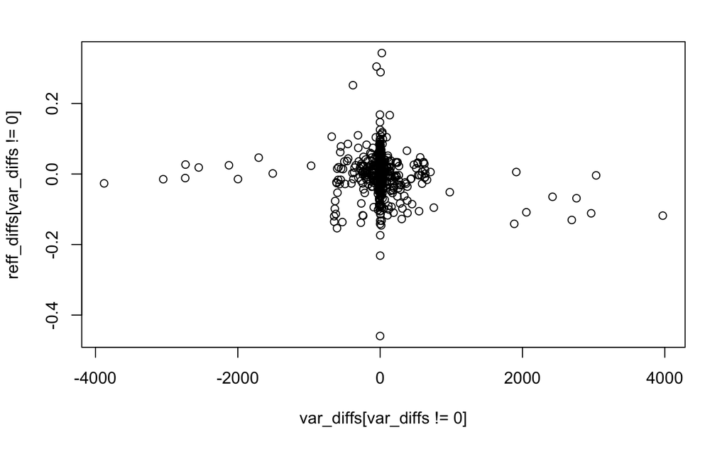